# Grup A · Pràctica 1 Química i Enginyeria de proteïnes.

Grup A - Sergi Gebellí, Marc Mulet, Alex Navarro, Ana Rodríguez, Guillem Sansalvador

2026-04-13

## 1) Seqüència analitzada

MSGEEERKEKREKVRAGLKRAIAELPAEVAARCLALLDDASDEEFIEAVLEVLEAMREALVAMAREGRLD AVRRATSHINEVLVDAAELALEKGREYFRRLCLIVCDMMIELIRLEPEQTPELRRIRERLEEIRRRLEGSG

## 2) Objectiu de la pràctica

El punt principal d’aquesta pràctica ha sigut assolir competències relacionades amb l’ús d’eines d’anàlisis, cerca d’homologies de seqüències proteiques amb el principal objectiu d’entendre i interpretar les representacions gràfiques de les diferents estructures proteiques. Identificant així diferents nivells estructurals de les proteïnes globulars i analitzar les regions implicades en la seva funció. També ha estat un dels objectius desenvolupar habilitats digitals en equip. L’estudi de les proteïes es essencial per entendre el mecanisme d’acció i la funció duns de la cèl·lula. En aquest context les eines bioinformàtiques ens permet analitzar amb detall les estrucutres tridimensionals de les proteïnes i establir relacions de forma i funció.

## 3) Introducció de la proteïna.

En aquesta pràctica hem estudiat com l’estructura tridimensional de la **proteïna Bcl-2-like**,(NCBI, s. f.) també coneguda com a **BIM**, amb codi **UniProt O43521**,(The UniProt Consortium, s. f.) influeix en la seva funció biològica. L’estructura utilitzada correspon a un constructe sintètic dissenyat de novo, format per dues cadenes: una cadena principal (A) de 141 aminoàcids i un pèptid associat (B) de 26 aminoàcids. Aquesta estructura permet analitzar amb detall les interaccions implicades en el reconeixement molecular característic d’aquest tipus de proteïnes.Per fer-ho, s’utilitzarà com a model l’estructura registrada amb el codi **pdb_00008t5e/ 8T5E** al Protein Data Bank (RCSB Protein Data Bank, s. f.). L’objectiu és caracteritzar els diferents nivells estructurals de la proteïna, identificar els elements funcionals.

La proteïna analitzada en aquest treball és una proteïna implicada en la regulació de l’apoptosi, concretament en la via intrínseca de mort cel·lular. Aquesta proteïna no presenta activitat enzimàtica i, per tant, no disposa de classificació EC ni de centre actiu catalític.

## 4) Desenvolupament

### Estructura secundària de la proteïna.

També identifiquem girs β i blucles Ω que conecten els diferents elemetns estructurals.  
Els girs β son els que permenen canvis bruscos de direcció en la cadena, contenen exactament 4 residus. Els bucles Ω corresponen a les regions més llargues i flexibles sense presentar una geometria definida.

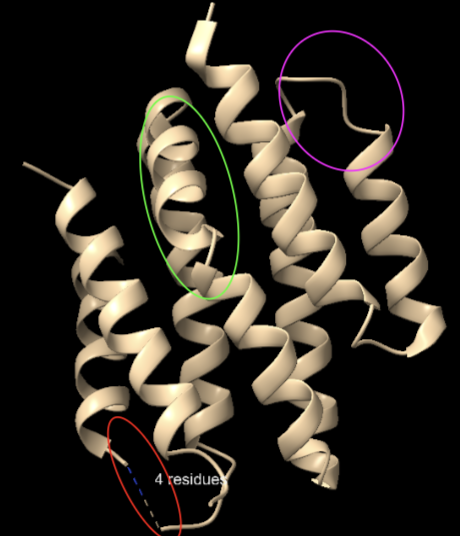

### Interaccions de la estructura secundària.

Les diferents estructures secundàries es troben estabilitzades per diversos tipus d’interaccions:

En les hèlixs α el principal element estabilitzador són els ponts d’hidrogen intracatenaris, que s’estabilitzen mitjançant enllaços entre el grup carbonil d’un aminoàcid i el grup amino del residu situat quatre posicions més endavant. Aquesta disposició dels enllaços peptídics genera un macrodipol helicoïdal amb l’extrem N-terminal parcialment positiu i el C-terminal parcialment negatiu. A més les cadenes laterals dels aminoàcids quden orientades cap a l’exterior i cap enrere de l’hèlix minimitzant aixì les repulsions estèriques, facilitant la interacció amb l’entorn i permetent una estructura compacta.

Tot i això, l’estabilitat de l’hèlix α no depèn únicament dels ponts d’hidrogen, sinó que també està influenciada per altres factors com les interaccions hidrofòbiques, electrostàtiques i la naturalesa dels aminoàcids.

Els girs β es mantenen estabilitzats degut també a ponts d’hidrogen entre residus i i+3 i es localitzen habitualment a la superfície de la proteïna, interactuant amb el solvent.

Els bucles Ω, per la seva banda, no presenten un patró regular d’enllaços d’hidrogen ja que no representen una geometria regular fica i són regions flexibles que faciliten la connexió entre elements estructurals de l’entorn. En la **Imatge 2** hi podem trobar representada la nostra proteïna amb els correspoenents ponts d’hidrogen.

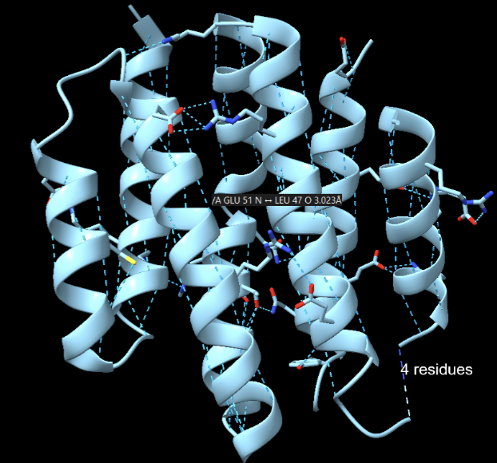

**Imatge 2.** Les linies discontinues blaves equivalen als ponts d’hidrogen

### Estructura supersecundària.

En les interaccions de van der Waals, que contenen un empaquetament hidrofòbic, en la representació 3D de l’**Imatge 3**, les línies verdes discontínues que creuen l’espai entre els diferents cilindres evidencien els contactes de van der Waals. Aquests es produeixen per l’estret empaquetament de les cadenes laterals dels aminoàcids que interactuen entre una hèlix i la seva veïna. Aquest fenomen permet amagar els residus hidrofòbics de l’aigua, formant el nucli (core) hidrofòbic que dóna estabilitat al domini sencer.

Pel que fa per als ponts d’hidrogen, en la imatge trobem etiquetat un pont d’hidrogen entre els residus ARG 132 i GLU 135. Aquesta distància exacta de 3 residus (regla i+3) és la interacció característica que estabilitza els girs estructurals que permeten a la cadena polipeptídica canviar de direcció i connectar les diferents hèlixs del motiu.

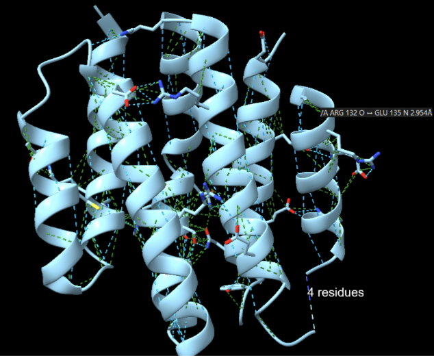

**Imatge 3.** Les linies discontinues verdes equivalen a les forces de Van der Waals

### Estructura terciària.

Pel que fa a l’estructura terciària, la nostra cadena presenta un plegament clarament de tipus α, compatible amb un α-helical bundle (feix d’hèlixs α). Això es pot inferir de la inspecció a ChimeraX, on la proteïna apareix formada gairebé exclusivament per hèlixs α i no mostra un nucli β ni un plegament α/β. Aquest tipus de plegaemnt és típuc de proteïnes implicades en interaccions proteïna - proteïna.

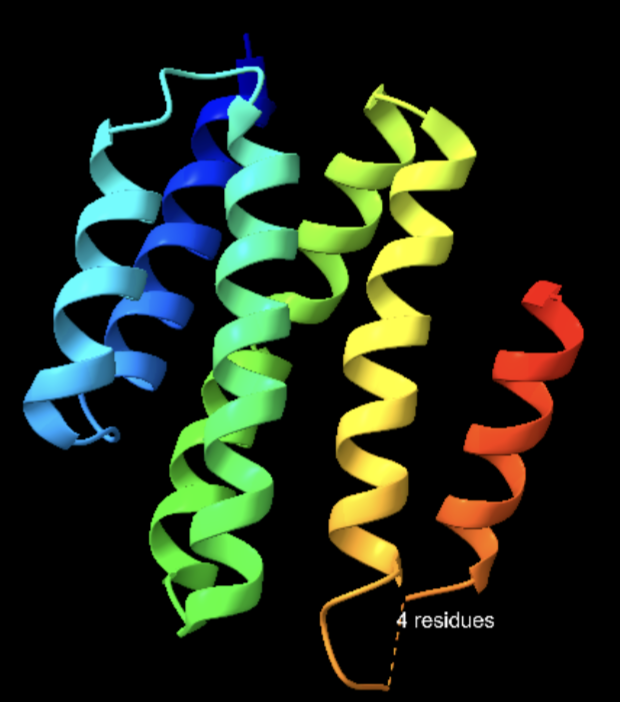

**Imatge 4.** Estructura terciària

### Dominis i classificació estrucutral.

En quant a l’estudi de dominis i família estructural, no s’ha trobat una classificació assignable per a 8T5E a CATH ni a ECOD, i tampoc una entrada útil de contrast a SCOPe en la cerca realitzada. Això és coherent amb la naturalesa de l’estructura, ja que RCSB l’anota explícitament com a proteïna dissenyada de novo / synthetic construct, és a dir, no necessàriament integrada en una família estructural i evolutiva clàssica prèviament catalogada. Per tant, en aquest cas, el tipus de plegament s’ha d’inferir principalment a partir de la inspecció estructural i de la descripció de l’entrada PDB.

### Estrucutura quaternària.

L’estructura quaternària correspon a un heterodímer asimètric A1B1. La cadena A és la proteïna globular principal i la cadena B és un pèptid curt que s’uneix al binder; per tant, no es tracta d’un oligòmer de subunitats equivalents, sinó d’un complex proteïna–pèptid, com podem observar en la **Imatge 5**.

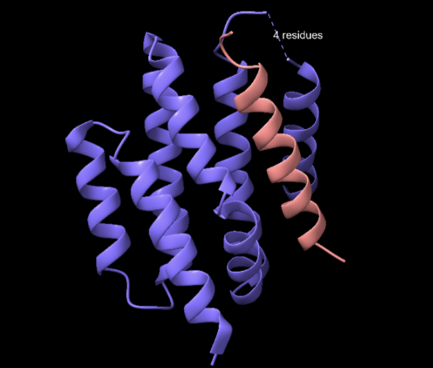

### Centre actiu.

BIM no presenta un centre actiu catalític, és a dir, no és una proteïna que catalitzi directament una reacció química com ho faria un enzim. El seu centre funcional és el motiu BH3 (Bcl-2 homology 3), que és una seqüència curta de residus aminoacídics conservada dins d’algunes proteïnes de la família BCL-2 i que és essencial per a les interaccions que regulen l’apoptosi. Aquest motiu és responsable de la unió de BIM a proteïnes antiapoptòtiques, és a dir, proteïnes que eviten o frenen la mort cel·lular programada, com ara BCL-XL, BCL-2 i MCL-1. Gràcies a aquesta unió, BIM pot exercir la seva activitat proapoptòtica, és a dir, afavorir l’activació de l’apoptosi.

Aquest motiu BH3 és la regió estructuralment més rellevant de BIM perquè és la que entra dins la solc hidrofòbic canònic, és a dir, una ranura de la proteïna receptora rica en residus hidrofòbics, on s’estableix la unió principal. En solució, BIM és majoritàriament una proteïna intrínsecament desordenada, és a dir, no adopta una estructura tridimensional rígida i estable quan està lliure. Tanmateix, quan s’uneix a la seva proteïna partner, el motiu BH3 adopta una α-hèlix funcional, que és un tipus d’estructura secundària helicoïdal habitual en moltes proteïnes i que permet un encaix correcte amb la proteïna diana.

### Residus i motius funcionals rellevants.

El pirmer motiu, el BH3 és clau per a la funció apoptòtica. La literatura estructural sobre BH3 mostra que la unió depèn sobretot de quatre residus hidrofòbics conservats de la cara de l’hèlix i d’un Asp conservat que estableix una interacció electrostàtica/salt bridge amb una Arg del partner antiapoptòtic.

Els residus clau del motiu BH3 inclouen Ile148, Leu152, Ile155, Asp157 i Phe159. Els residus hidrofòbics participen en la interacció amb butxaques hidrofòbiques del partner, mentre que Asp157 estableix una interacció electrostàtica conservada amb una arginina.

El segon motiu d’unió és a DYNLL1/LC8, BIM també està regulada per la seva unió a la cadena lleugera de dineïna DYNLL1 (LC8), cosa que la manté associada al complex motor/microtúbuls en cèl·lules sanes. Aquest motiu no és el principal lloc apoptòtic final, però és un motiu regulador important perquè controla la disponibilitat de BIM.

I per últim en les regions fosforilables de BIMEL, l’isoforma BIMEL té una regió addicional amb llocs de fosforilació reguladors. En humans, Ser69 és especialment important: la fosforilació per ERK1/2 afavoreix la dissociació de BIMEL de MCL-1/BCL-XL i també en pot promoure la degradació; a més, RSK1/2 fosforila serines d’un degró que afavoreix el reconeixement per βTrCP i la degradació proteasòmica.

### Substrat o inhibidor.

No conté cap substrat. Com s’ha indicat anteriorment, BIM no és un enzim i, per tant, no transforma cap substrat químicament. L’estructura 8T5E correspon a un complex (un heterodímer asimètric A1B1). En aquest cas, la cadena principal (cadena A) actua com a “receptor” o binder dissenyat per reconèixer un pèptid. Des d’un punt de vista funcional, el fregament de la proteïna BIM (específicament el seu motiu BH3) actua com un inhibidor de les proteïnes antiapoptòtiques (com BCL-2 o MCL-1). En bloquejar el solc hidrofòbic d’aquestes proteïnes protectores, BIM “inhibeix l’inhibidor” de la mort cel·lular, permetent que l’apoptosi segueixi endavant

### Interaccions funcionals.

Com que BIM no presenta un centre catalític actiu, en aquest cas es parla d’un centre d’unió funcional. El motiu BH3 de BIM interacciona amb proteïnes antiapoptòtiques de la família BCL-2, com BCL-XL, MCL-1 i altres proteïnes semblants, mitjançant la seva unió a la seva solc hidrofòbica. En aquesta interacció, la regió BH3 adopta una estructura d’α-hèlix amfipàtica.

Els residus hidrofòbics Ile148, Leu152, Ile155 i Phe159 s’insereixen en butxaques hidrofòbiques del partner, contribuint de manera principal a l’estabilització del complex a través d’interaccions de van der Waals i de l’efecte hidrofòbic. Al mateix temps, Asp157 estableix una interacció electrostàtica amb una arginina conservada de la proteïna receptora (per exemple, Arg263 en MCL-1 o residus arginina equivalents en altres membres de la família BCL-2). Aquest patró d’unió està dominat per interaccions hidrofòbiques/van der Waals, reforçades per ponts d’hidrogen i una sal bridge conservada.

### Funció biològica.

BIM no és un enzim, de manera que no catalitza cap reacció química ni segueix un mecanisme enzimàtic. La seva funció és principalment reguladora dins la via intrínseca de l’apoptosi. Segons UniProt, es descriu com una proteïna capaç d’induir apoptosi i anoikis.

El mecanisme funcional de BIM es pot resumir de la següent manera: en resposta a estrès cel·lular, retirada de factors de supervivència o altres senyals proapoptòtics, BIM s’activa o s’allibera. Un cop actiu, el seu motiu BH3 s’uneix a proteïnes antiapoptòtiques de la família BCL-2, com BCL-2, BCL-XL o MCL-1, neutralitzant així la seva funció protectora.

A més, BIM pot contribuir a l’activació de les proteïnes efectores BAX/BAK1, responsables de la permeabilització de la membrana externa mitocondrial. Aquest procés desencadena la MOMP (mitochondrial outer membrane permeabilization), que provoca l’alliberament de factors proapoptòtics com el citocrom c i l’activació de la cascada apoptòtica.

Finalment, BIM també participa en la regulació de la relació entre autofàgia i apoptosi: quan s’uneix a DYNLL1, pot reclutar BECN1 als microtúbuls i inhibir l’autofàgia. En determinades condicions, la fosforilació de BIM per quinases com JNK/MAPK8 afavoreix la dissociació d’aquest complex, modulant així aquest equilibri cel·lular.

### Modificacions post-traduccionals.

BIM presenta diverses modificacions posttraduccionals rellevants des del punt de vista funcional, especialment en la seva isoforma BIMEL.

La més ben documentada és la fosforilació. En humans, la fosforilació del residu Ser69 per ERK1/2 és especialment important, ja que pot afavorir la dissociació de BIMEL de proteïnes antiapoptòtiques com MCL-1 o BCL-XL. A més, aquesta modificació “prepara” la proteïna per a fosforilacions addicionals que en promouen la degradació. En un degró conservat de BIMEL, les quinases Rsk1/2 fosforilen diverses serines, fet que facilita la unió de βTrCP i la posterior degradació proteasòmica. D’altra banda, en el context de la regulació entre autofàgia i apoptosi, la fosforilació de BIM per JNK/MAPK8 pot abolir la seva interacció amb DYNLL1.

Una altra modificació clau és la ubiquitinació. La degradació de BIMEL depèn en gran mesura d’aquest procés, que sovint és afavorit per la fosforilació prèvia. Això permet un control molt fi de la quantitat de BIM activa dins la cèl·lula i, per tant, de la seva capacitat proapoptòtica.

Pel que fa als residus diana potencials, destaquen principalment els residus Ser/Thr de la regió reguladora específica de BIMEL, especialment Ser69. També són rellevants els residus implicats en el motiu d’unió a DYNLL1, on la fosforilació pot alterar la interacció amb LC8. Finalment, diverses lisines poden actuar com a punts d’ubiquitinació, especialment en el context de la degradació regulada de BIMEL.

### Relació estructura-funció.

L’estructura de BIM està adaptada a una funció de reconeixement proteïna-proteïna més que no pas a una funció catalítica. BIM és majoritàriament desordenada quan està lliure, i això li dóna flexibilitat reguladora; però el seu motiu BH3 pot ordenar-se en α-hèlix quan troba el partner correcte. Aquesta transició desordre → hèlix és clau perquè BIM pugui unir-se amb gran afinitat a diverses proteïnes antiapoptòtiques i actuar com a sensor/integrador de senyals de mort cel·lular.

### Elements estrucuturals.

El motiu BH3 és un dels elemts estructurals implicats en la funció BIm. Aquest que és l’element central d’unió a proteïnes de la família BCL-2. Quan s’uneix al seu partner, adopta una estructura d’α-hèlix, que permet el reconeixement funcional.

Continuant amb la regió N-terminal, que conté el motiu d’unió a DYNLL1, regula la localització cel·lular i la disponibilitat funcional de BIM.

Finalment, la regió específica de BIMEL, amb múltiples llocs de fosforilació, actua com a element regulador que controla l’estabilitat, l’activitat i la degradació de la proteïna.

### Residus claus.

Els principals residus implicats en la funció de BIM es poden resumir segons el seu paper estructural i regulador.

Dins el motiu BH3, els residus Ile148, Leu152, Ile155 i Phe159 constitueixen el nucli hidrofòbic principal, essencial per a la interacció amb les proteïnes antiapoptòtiques de la família BCL-2. En aquest mateix motiu, Asp157 és un residu carregat conservat que té un paper crític en la formació d’un pont salí (salt bridge) amb un residu d’arginina del partner, estabilitzant així el complex d’unió.

En la isoforma BIMEL, el residu Ser69 és un punt regulador clau, ja que la seva fosforilació per ERK1/2 modula l’activitat de la proteïna i pot influir en la seva estabilitat i degradació. Finalment, els residus implicats en el motiu d’unió a DYNLL1 formen una regió reguladora important per al segrest de BIM als microtúbuls i la modulació de la seva funció proapoptòtica, encara que en una descripció estructural rigorosa és preferible referir-s’hi com a motiu funcional regulador si no es disposa de la numeració exacta validada per a una estructura concreta.

### Variants.

La variant més coneguda i amb més rellevància biomèdica no és tant una mutació puntual de la proteïna, sinó una deleció polimòrfica a l’intró 2 de BCL2L11. Aquesta deleció altera l’splicing i afavoreix isoformes que perden el domini BH3, de manera que es redueix la capacitat proapoptòtica i pot aparèixer resistència intrínseca a inhibidors de tirosina quinasa (TKI) en alguns contextos, com CML o NSCLC amb EGFR.

## 5) Discussió

Els resultats d’aquesta pràctica mostren que la funció de la proteïna està estretament lligada a la seva funció i la capacitat d’interacció amb altres proteïnes. L’estrucutura basada en hèlixs α proporciona estabilitat, mentre que les regions flexibles permeten adaptabilitat funcional

El motiu BH3 és un exemple de com uan regió estructural pot dererminar la funicó global de la proteïna. La capacitat de formar una hèlix α només en presència del partner refelcteix un mecanisme d’adaptació estructural que optimitza la unió

## 6) Conclusions

L’estudi demostra que la proteïna BIM és un regulador clau de l’apoptosi la funció del qual depèn de la seva estructura i dinàmica conformacional. Tot i no presentar activitat enzimàtica, la seva arquitectura basada en hèlixs α i la presència del motiu BH3 li permeten establir interaccions específiques amb proteïnes antiapoptòtiques.

El plegament de tipus α-helical bundle proporciona estabilitat estructural, mentre que la flexibilitat de determinades regions permet adaptar-se a diferents partners moleculars. La transició del motiu BH3 d’un estat desordenat a una hèlix estructurada és un element clau en el mecanisme de reconeixement.

A més, la regulació mitjançant modificacions post-traduccionals i l’existència de variants que afecten el motiu funcional evidencien la importància de la seva estructura en la seva funció biològica.

En conclusió aquets treball es centra en l’explicació de la importància de la relació estructura-funció en proteïnes no enzimàtiques, i en aquest cas sintetitzada de novo,explicant com els elements estructurals poden determinar processos cel·lulars essencials com l’aptotsi.

## 7) Bibliografia

RCSB Protein Data Bank. (s. f.). RCSB PDB: Homepage.

The UniProt Consortium. (s. f.). UniProt.

UCSF RBVI. (2024). UCSF ChimeraX (version 1.11.1)

National Center for Biotechnology Information (NCBI). (s. f.). Gene: BCL2L11 (BIM).

Youle, R. J., & Strasser, A. (2008). The BCL-2 protein family: opposing activities that mediate cell death. Nature Reviews Molecular Cell Biology, 9, 47–59.

Sattler, M., et al. (1997). Structure of Bcl-xL–Bak peptide complex: recognition between regulators of apoptosis. Molecular Cell, 1, 783–793.

Ley, R., et al. (2003). ERK1/2-dependent phosphorylation of BimEL promotes its degradation. Molecular Cell, 11, 561–574.